# Week9_Broken

## Data 110.DS1

## March 14, 2021

## Week 9 - NLP Text Classification

```python
import nltk
import pandas as pd
import numpy as np
from collections import Counter
import string


from nltk import word_tokenize
from nltk.stem import WordNetLemmatizer
from nltk.tokenize import RegexpTokenizer
from nltk.corpus import stopwords
from nltk.probability import FreqDist



import texthero as hero
from texthero import preprocessing

import matplotlib.pyplot as plt
import seaborn as sns
```

## Import

```python
df = pd.read_csv('spam.csv')

df_vanilla = df
```

## EDA

```python
df.shape
```

```
(5572, 2)
```

```python
df.describe()
```

|  | label | text |
| --- | --- | --- |
| count | 5572 | 5572 |
| unique | 2 | 5169 |
| top | ham | Sorry, I'll call later |
| freq | 4825 | 30 |

```python
s1 = sum(df['text'].str.split().str.len())
print('There are:',s1,'words in the dataset before preprocessing')
```

```
There are: 86335 words in the dataset before preprocessing
```

```python
df.head(5)
```

|  | label | text |
| --- | --- | --- |
| 0 | ham | Go until jurong point, crazy.. Available only ... |
| 1 | ham | Ok lar... Joking wif u oni... |
| 2 | spam | Free entry in 2 a wkly comp to win FA Cup fina... |
| 3 | ham | U dun say so early hor... U c already then say... |
| 4 | ham | Nah I don't think he goes to usf, he lives aro... |

```python
df['length'] = df['text'].apply(len)
```

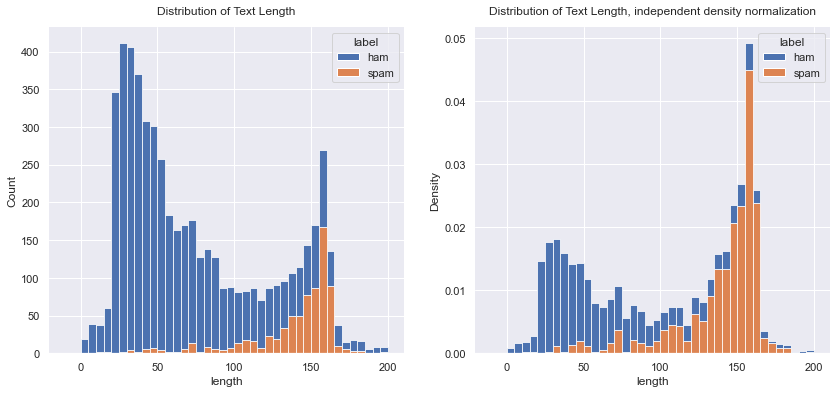

```python
sns.set_theme(style="darkgrid")
plt.figure(figsize=(14, 6))

plt.subplot(1, 2, 1)
sns.histplot(data=df, x='length', binwidth=5, binrange=( -10, 200), color='tab:blue', alpha=1, hue='label', multiple="stack")
plt.title("Distribution of Text Length", y = 1.02)

plt.subplot(1, 2, 2)
sns.histplot(data=df, x='length', binwidth=5,binrange=( -10, 200), color='tab:blue', alpha=1, hue='label', multiple="stack", stat="density", common_norm=False)
plt.title("Distribution of Text Length, independent density normalization", y = 1.02)

sns.despine(left=True)
plt.show()
```

**Note that word Frequency will be addressed after pre-processing.** This is because we're using words to help classify instead of generate sentiment. It makes less sense to remove a particular word that might be used a lot in either label, since that would reduce the amount of information available to models. Typically I'd generate word frequency here to use as a baseline for measuring how much cleaning accomplished(and what needs to be manually cleaned), but since I'm not interesting in removing more words than standard cleaning already does, I'm electing to defer word frequency until after cleaning.

## PreProcessing

### Cleaning

```python
df['text'] = hero.clean(df['text']) #accomplishes most cleaning previously done using user-defined functions. See References.
```

```python
df.head(5)
```

|  | label | text | length |
| --- | --- | --- | --- |
| 0 | ham | go jurong point crazy available bugis n great ... | 111 |
| 1 | ham | ok lar joking wif u oni | 29 |
| 2 | spam | free entry wkly comp win fa cup final tkts 21s... | 155 |
| 3 | ham | u dun say early hor u c already say | 49 |
| 4 | ham | nah think goes usf lives around though | 61 |

### Tokenize/Lemmatize

```python
def identify_tokens(df):
    row = df['text']
    tokens = nltk.word_tokenize(row)
    return tokens

df['tokens'] = df.apply(identify_tokens, axis=1)
```

```python
df.head(5)
```

|  | label | text | length | tokens |
| --- | --- | --- | --- | --- |
| 0 | ham | go jurong point crazy available bugis n great ... | 111 | [go, jurong, point, crazy, available, bugis, n... |
| 1 | ham | ok lar joking wif u oni | 29 | [ok, lar, joking, wif, u, oni] |
| 2 | spam | free entry wkly comp win fa cup final tkts 21s... | 155 | [free, entry, wkly, comp, win, fa, cup, final,... |
| 3 | ham | u dun say early hor u c already say | 49 | [u, dun, say, early, hor, u, c, already, say] |
| 4 | ham | nah think goes usf lives around though | 61 | [nah, think, goes, usf, lives, around, though] |

```python
def lemmatize_text(text):
    lemmatizer = nltk.WordNetLemmatizer()
    return [lemmatizer.lemmatize(w) for w in text]
```

```python
df['lems'] = df['tokens'].apply(lemmatize_text)

# Subset necessary columns
df2 = df[['label', 'lems', 'length']]

df2.head(5)
```

|  | label | lems | length |
| --- | --- | --- | --- |
| 0 | ham | [go, jurong, point, crazy, available, bugis, n... | 111 |
| 1 | ham | [ok, lar, joking, wif, u, oni] | 29 |
| 2 | spam | [free, entry, wkly, comp, win, fa, cup, final,... | 155 |
| 3 | ham | [u, dun, say, early, hor, u, c, already, say] | 49 |
| 4 | ham | [nah, think, go, usf, life, around, though] | 61 |

```python
df2.head(5)
```

|  | label | lems | length |
| --- | --- | --- | --- |
| 0 | ham | [go, jurong, point, crazy, available, bugis, n... | 111 |
| 1 | ham | [ok, lar, joking, wif, u, oni] | 29 |
| 2 | spam | [free, entry, wkly, comp, win, fa, cup, final,... | 155 |
| 3 | ham | [u, dun, say, early, hor, u, c, already, say] | 49 |
| 4 | ham | [nah, think, go, usf, life, around, though] | 61 |

### Post-Process EDA

```python
# s = sum(df['text'].str.split().str.len())
print('There were',s1,'words in the dataset before preprocessing')

s2 = len(df2['lems'].str.split()) - 1
print('There are',s2,'words in the dataset after preprocessing')

print('Pre-processing removed/changed', s1-s2, 'words')
```

```
There were 86335 words in the dataset before preprocessing
There are 5571 words in the dataset after preprocessing
Pre-processing removed/changed 80764 words
```

```python
# fdist most_common apparently doesn't work well within a DF so I'm using this in lieu of that function
def word_frequency(df):
    words = df.sum()
    count = Counter(words)
    count = pd.DataFrame.from_records(count.most_common(), columns=['word','count'])
    count['word'] = count['word'].str.lower()
    count = count.head(15)
    print(count)
```

```python
spam = df2[df2['label'].str.contains('spam')]
ham = df2[df2['label'].str.contains('ham')]
```

```python
print('Word Frequency in Spam')
word_frequency(spam['lems'])
```

```
Word Frequency in Spam
      word  count
0     call    367
1      aps    293
2     free    224
3        u    182
4      txt    163
5     text    144
6       ur    144
7   mobile    139
8     stop    119
9    claim    115
10   reply    105
11       c    100
12     www     98
13   prize     95
14     get     86
```

In a typical scenario I might choose to remove some instances, 'www' for example. However since we're trying to tag spam, I think it makes sense to leave these, since they are good 'pointers' for a spam label.

```python
print('Word Frequency in ham')
word_frequency(ham['lems'])
```

```
Word Frequency in ham
    word  count
0      u   1090
1     gt    318
2     lt    316
3    get    315
4     ok    287
5     go    276
6   call    251
7   know    245
8   come    245
9    got    242
10    ur    237
11   day    236
12  like    235
13  good    234
14  time    226
```

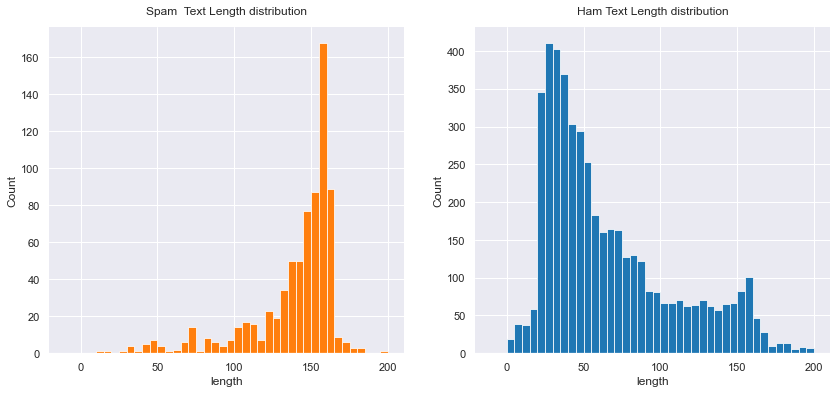

```python
sns.set_theme(style="darkgrid")
plt.figure(figsize=(14, 6))

plt.subplot(1, 2, 1)
sns.histplot(data=spam, x='length', binwidth=5, binrange=( -10, 200), color='tab:orange', alpha=1,)
plt.title("Spam  Text Length distribution", y = 1.02)

plt.subplot(1, 2, 2)
sns.histplot(data=ham, x='length', binwidth=5,binrange=( -10, 200), color='tab:blue', alpha=1)
plt.title("Ham Text Length distribution", y = 1.02)

sns.despine(left=True)
plt.show()
```

# Modeling Prep

```python
from sklearn import model_selection
from sklearn.feature_extraction.text import TfidfVectorizer, CountVectorizer
from sklearn.model_selection import train_test_split
from sklearn.naive_bayes import MultinomialNB
from sklearn import metrics
from nltk.tokenize import RegexpTokenizer

# Scoring tools
from sklearn.model_selection import cross_val_score,GridSearchCV
from sklearn.metrics import confusion_matrix, plot_confusion_matrix, accuracy_score, classification_report, roc_auc_score
from sklearn.datasets import make_classification
from sklearn.dummy import DummyClassifier
from sklearn.calibration import CalibratedClassifierCV

# Models
from sklearn.linear_model import RidgeClassifier, SGDClassifier, LogisticRegression
from sklearn.svm import SVC, NuSVC, LinearSVC
from sklearn.neighbors import KNeighborsClassifier,NearestCentroid,RadiusNeighborsClassifier
from sklearn.tree import DecisionTreeClassifier, ExtraTreeClassifier
from sklearn import ensemble
from sklearn.ensemble import AdaBoostClassifier,BaggingClassifier,ExtraTreesClassifier, GradientBoostingClassifier, RandomForestClassifier,StackingClassifier
```

```python
#Reconfigure DF for SKLearn Usage
df2['text'] = df2['lems'] .apply(lambda x: ','.join(map(str, x)))

df2 = df2.drop(columns=['lems','length'])
```

# Modeling

## SKlearn Bag of Words

```python
cv = CountVectorizer() #BoW
text_counts= cv.fit_transform(df2['text'])

x = text_counts
y = df2['label']

x_train, x_test, y_train, y_test = train_test_split(x, y, test_size=0.2, random_state=79, shuffle=True)
```

According to Sklearn documention, CountVectorizer takes care of a lot of pre-processing natively. As already shown, I did a lot of pre-processing in the interest of practice and thoroughness. Got to discover a more sklearn fun stuff in the process, along with a text cleaning package.

```python
#Dummy Model Bag of words
dummy_model = DummyClassifier(strategy='stratified', random_state=79)
dummy_model.fit(x_train, y_train)
dummy_yhat = dummy_model.predict_proba(x_test)
dummy_pos_probs = dummy_yhat[:, 1]

dummy_roc_auc = roc_auc_score(y_test, dummy_pos_probs)
```

```python
models = []

# Linear Models
models.append(('Linear Ridge', RidgeClassifier()))
models.append(('Linear SGD', SGDClassifier()))
models.append(('Linear Logistic', LogisticRegression()))

# SVM Machines
models.append(('SVM SVC', SVC()))
models.append(('SVM NuSVC', NuSVC()))
models.append(('SVM LinearSVC', LinearSVC()))

# Nearest Neighbor
models.append(('KNN Neighbor', KNeighborsClassifier()))
models.append(('KNN Centroid', NearestCentroid()))
models.append(('KNN Radius Neighbor', RadiusNeighborsClassifier()))

# Decision Tree
models.append(('Tree Decision Tree', DecisionTreeClassifier()))
models.append(('Tree Extra Tree', ExtraTreeClassifier()))

#Ensemble
models.append(('Ensemble ADA Boost', AdaBoostClassifier()))
models.append(('Ensemble Bagging', BaggingClassifier()))
models.append(('Ensemble Extra Trees', ExtraTreesClassifier()))
models.append(('Ensemble Gradient Boost', GradientBoostingClassifier()))
models.append(('Ensemble Random Forest', RandomForestClassifier()))


results = []
names = []
results = []
names = []
scorers = ['precision_macro', 'recall_macro', 'f1_macro']

for name, model in models:
         kfold = model_selection.KFold(n_splits=10, random_state=79, shuffle=True)
         cv_results = model_selection.cross_validate(model, x_train, y_train, cv=kfold, scoring=scorers, n_jobs=-1, return_train_score=True)
         results.append(cv_results)
         names.append(name)
         print(f" {name}, Precision: {round(np.mean(cv_results['test_precision_macro']), 2)} -- F1: {round(np.mean(cv_results['test_f1_macro']), 2)} -- Fit Time: {round(np.mean(cv_results['fit_time']), 3)}")
```

```
 Linear Ridge, Precision: 0.98 -- F1: 0.94 -- Fit Time: 0.039
 Linear SGD, Precision: 0.97 -- F1: 0.95 -- Fit Time: 0.01
 Linear Logistic, Precision: 0.98 -- F1: 0.95 -- Fit Time: 0.138
 SVM SVC, Precision: 0.98 -- F1: 0.94 -- Fit Time: 0.531
 SVM NuSVC, Precision: nan -- F1: nan -- Fit Time: 0.01
 SVM LinearSVC, Precision: 0.98 -- F1: 0.96 -- Fit Time: 0.019
 KNN Neighbor, Precision: 0.96 -- F1: 0.76 -- Fit Time: 0.005
 KNN Centroid, Precision: 0.94 -- F1: 0.92 -- Fit Time: 0.008
 KNN Radius Neighbor, Precision: nan -- F1: nan -- Fit Time: 0.011
 Tree Decision Tree, Precision: 0.95 -- F1: 0.93 -- Fit Time: 0.085
 Tree Extra Tree, Precision: 0.93 -- F1: 0.92 -- Fit Time: 0.072
 Ensemble ADA Boost, Precision: 0.95 -- F1: 0.93 -- Fit Time: 1.517
 Ensemble Bagging, Precision: 0.96 -- F1: 0.94 -- Fit Time: 0.569
 Ensemble Extra Trees, Precision: 0.99 -- F1: 0.96 -- Fit Time: 7.421
 Ensemble Gradient Boost, Precision: 0.97 -- F1: 0.93 -- Fit Time: 3.011
 Ensemble Random Forest, Precision: 0.98 -- F1: 0.95 -- Fit Time: 3.461
```

```
              precision    recall  f1-score   support

         ham       0.97      0.99      0.98       969
        spam       0.90      0.81      0.85       146

    accuracy                           0.96      1115
   macro avg       0.94      0.90      0.92      1115
weighted avg       0.96      0.96      0.96      1115
```

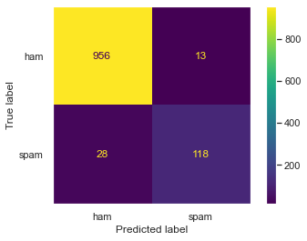

```
Dummy AUC-ROC: 0.523
BoW Unbalanced AUC-ROC: 0.897
```

```python
# BoW
# ExtraTreeClassifier
# Unbalanced
XTC1 = ExtraTreeClassifier(random_state=79)

XTC1.fit(x_train, y_train)

# predict
y_pred= XTC1.predict(x_test)

# access performance
print(classification_report(y_test, y_pred, digits=2))

plot_confusion_matrix(XTC1, x_test, y_test)
plt.grid(False)
plt.show()

# AUC- ROC
yhat = XTC1.predict_proba(x_test)
pos_probs = yhat[:, 1]
roc_auc = roc_auc_score(y_test, pos_probs)

print('Dummy AUC-ROC: %.3f' % dummy_roc_auc)
print('BoW Unbalanced AUC-ROC: %.3f' % roc_auc)
```

```python
results = [{'Vector':'BoW', 'Model Name':'ExtraTreeClassifier', 'Method':'Unbalanced','F1 Score':0.96,'AUC-ROC': 0.897}]
results_df = pd.DataFrame(results)
results_df
```

|  | Vector | Model Name | Method | F1 Score | AUC-ROC |
| --- | --- | --- | --- | --- | --- |
| 0 | BoW | ExtraTreeClassifier | Unbalanced | 0.96 | 0.897 |

```
              precision    recall  f1-score   support

         ham       0.97      0.98      0.98       969
        spam       0.86      0.82      0.84       146

    accuracy                           0.96      1115
   macro avg       0.92      0.90      0.91      1115
weighted avg       0.96      0.96      0.96      1115
```

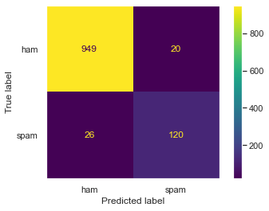

```
Dummy AUC-ROC: 0.523
TD-IDF Balanced AUC-ROC: 0.901
```

```python
# BoW
# ExtraTreeClassifier
# Balanced
XTC1_bal = ExtraTreeClassifier(random_state=79, class_weight='balanced')

XTC1_bal.fit(x_train, y_train)

# predict
y_pred= XTC1_bal.predict(x_test)

# access performance
print(classification_report(y_test, y_pred, digits=2))

plot_confusion_matrix(XTC1_bal, x_test, y_test)
plt.grid(False)
plt.show()

# AUC- ROC
yhat = XTC1_bal.predict_proba(x_test)
pos_probs = yhat[:, 1]
roc_auc = roc_auc_score(y_test, pos_probs)

print('Dummy AUC-ROC: %.3f' % dummy_roc_auc)
print('TD-IDF Balanced AUC-ROC: %.3f' % roc_auc)
```

```python
results = [{'Vector':'BoW', 'Model Name':'ExtraTreeClassifier', 'Method':'Balanced','F1 Score':0.96,'AUC-ROC': 0.901}]
results_df =  results_df.append(results)
results_df
```

|  | Vector | Model Name | Method | F1 Score | AUC-ROC |
| --- | --- | --- | --- | --- | --- |
| 0 | BoW | ExtraTreeClassifier | Unbalanced | 0.96 | 0.897 |
| 0 | BoW | ExtraTreeClassifier | Balanced | 0.96 | 0.901 |

```
              precision    recall  f1-score   support

         ham       0.99      1.00      0.99       969
        spam       0.99      0.92      0.95       146

    accuracy                           0.99      1115
   macro avg       0.99      0.96      0.97      1115
weighted avg       0.99      0.99      0.99      1115
```

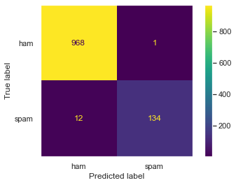

```
Dummy AUC-ROC: 0.523
BoW Unbalanced AUC-ROC: 0.992
```

```python
# BoW
# LinearSVC
# Unbalanced
LSVC = LinearSVC(random_state=79)
CLF_SVC1 = CalibratedClassifierCV(LSVC) #adds predict_proba functionality for LinearSVC

CLF_SVC1.fit(x_train, y_train)

# predict
y_pred= CLF_SVC1.predict(x_test)

# access performance
print(classification_report(y_test, y_pred, digits=2))

plot_confusion_matrix(CLF_SVC1, x_test, y_test)
plt.grid(False)
plt.show()

# AUC- ROC
yhat = CLF_SVC1.predict_proba(x_test)
pos_probs = yhat[:, 1]
roc_auc = roc_auc_score(y_test, pos_probs)

print('Dummy AUC-ROC: %.3f' % dummy_roc_auc)
print('BoW Unbalanced AUC-ROC: %.3f' % roc_auc)
```

```python
results = [{'Vector':'BoW', 'Model Name':'LinearSVC', 'Method':'Unbalanced','F1 Score':0.99,'AUC-ROC': 0.992}]
results_df =  results_df.append(results)
results_df
```

|  | Vector | Model Name | Method | F1 Score | AUC-ROC |
| --- | --- | --- | --- | --- | --- |
| 0 | BoW | ExtraTreeClassifier | Unbalanced | 0.96 | 0.897 |
| 0 | BoW | ExtraTreeClassifier | Balanced | 0.96 | 0.901 |
| 0 | BoW | LinearSVC | Unbalanced | 0.99 | 0.992 |

```
              precision    recall  f1-score   support

         ham       0.99      1.00      0.99       969
        spam       0.98      0.92      0.95       146

    accuracy                           0.99      1115
   macro avg       0.98      0.96      0.97      1115
weighted avg       0.99      0.99      0.99      1115
```

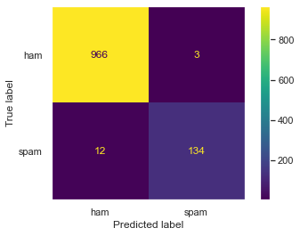

```
Dummy AUC-ROC: 0.523
TD-IDF Unbalanced AUC-ROC: 0.991
```

```python
# BoW
# LinearSVC
# Balanced
LSVC = LinearSVC(random_state=79, class_weight='balanced')
CLF_LSVC1_bal = CalibratedClassifierCV(LSVC) #adds predict_proba functionality for LinearSVC

CLF_LSVC1_bal.fit(x_train, y_train)

# predict
y_pred= CLF_LSVC1_bal.predict(x_test)

# access performance
print(classification_report(y_test, y_pred, digits=2))

plot_confusion_matrix(CLF_LSVC1_bal, x_test, y_test)
plt.grid(False)
plt.show()

# AUC- ROC
yhat = CLF_LSVC1_bal.predict_proba(x_test)
pos_probs = yhat[:, 1]
roc_auc = roc_auc_score(y_test, pos_probs)

print('Dummy AUC-ROC: %.3f' % dummy_roc_auc)
print('TD-IDF Unbalanced AUC-ROC: %.3f' % roc_auc)
```

```python
results = [{'Vector':'BoW','Model Name':'LinearSVC', 'Method':'Balanced','F1 Score':0.99,'AUC-ROC': 0.991}]
results_df =  results_df.append(results)
results_df
```

|  | Vector | Model Name | Method | F1 Score | AUC-ROC |
| --- | --- | --- | --- | --- | --- |
| 0 | BoW | ExtraTreeClassifier | Unbalanced | 0.96 | 0.897 |
| 0 | BoW | ExtraTreeClassifier | Balanced | 0.96 | 0.901 |
| 0 | BoW | LinearSVC | Unbalanced | 0.99 | 0.992 |
| 0 | BoW | LinearSVC | Balanced | 0.99 | 0.991 |